## Sampling methods

Location information

| Spp | Source_St | Source_County | n |
| --- | --- | --- | --- |
| LABO | DE |  | 3 |
| LABO | IL |  | 8 |
| LABO | IN |  | 30 |
| LABO | MD | Allegany | 14 |
| LABO | MD | Carroll | 2 |
| LABO | MD | Garrett | 13 |
| LABO | MD | Washington | 3 |
| LABO | MD |  | 4 |
| LABO | NY | – | 1 |
| LABO | OH | Paulding | 1 |
| LABO | OH | Van Wert | 1 |
| LABO | WV | Greenbrier and Nicholas Counties | 9 |
| LABO | WV |  | 6 |
| LACI | CA | Contra Costa | 1 |
| LACI | IL |  | 11 |
| LACI | IN |  | 23 |
| LACI | MD | Garrett | 1 |
| LACI | MD |  | 2 |
| LACI | NV | White Pine Co. | 1 |
| LACI | NY |  | 16 |
| LACI | OH | Van Wert | 5 |
| LACI | PA |  | 9 |
| LACI | WV | Greenbrier and Nicholas Counties | 2 |
| LACI | WV |  | 4 |
| LANO | ID |  | 54 |
| LANO | IL |  | 1 |
| LANO | IN |  | 21 |
| LANO | MD | Allegany | 2 |
| LANO | NY |  | 11 |
| LANO | OH | Paulding | 1 |
| LANO | OH | Van Wert | 2 |
| LANO | RI | Providence | 2 |
| LANO | WV | Greenbrier and Nicholas Counties | 8 |

##### Data from Table 1: Individuals of each species sampled by state and range of years and month of year sampled.

| Spp | Source_St | range_year | range_month | n_indiv |
| --- | --- | --- | --- | --- |
| LABO | DE | 2015 | 7 | 3 |
| LABO | IL | 2015 | 7 - 8 | 8 |
| LABO | IN | 2009 - 2014 | 7 - 10 | 30 |
| LABO | MD | 2011 - 2017 | 6 - 10 | 36 |
| LABO | NY | 2010 | Inf | 1 |
| LABO | OH | 2014 - 2016 | 5 - 6 | 2 |
| LABO | WV | 2011 - 2015 | 9 - 10 | 15 |
| LACI | CA | 2016 | 6 | 1 |
| LACI | IL | 2015 - 2018 | 8 | 11 |
| LACI | IN | 2009 - 2014 | 4 - 10 | 23 |
| LACI | MD | 2003 - 2017 | 7 - 10 | 3 |
| LACI | NV | 2013 | 10 | 1 |
| LACI | NY | 2008 - 2009 | 8 | 16 |
| LACI | OH | 2014 | 6 - 8 | 5 |
| LACI | PA | 2013 | 6 - 9 | 9 |
| LACI | WV | 2011 - 2016 | 5 - 10 | 6 |
| LANO | ID | 2012 - 2015 | 6 - 10 | 54 |
| LANO | IL | 2018 | 8 | 1 |
| LANO | IN | 2009 - 2014 | 4 - 10 | 21 |
| LANO | MD | 2015 | 5 | 2 |
| LANO | NY | 2009 - 2010 | 6 - 8 | 11 |
| LANO | OH | 2014 - 2016 | 6 - 8 | 3 |
| LANO | RI | 2014 - 2018 | 8 | 2 |
| LANO | WV | 2015 | 9 - 10 | 8 |

We conducted qPCR on a total of 322 samples representing 272 individuals (76 samples from 75 individual hoary bats, 119 samples from 95 individual eastern red bats, and 127 samples from 102 individual silver-haired bats; Table 2).

##### Data included in Table 2: Number of individuals sampled by each sampling method. Note that individuals sampled by multiple methods (e.g., “tissue and skin swab”) correspond with multiple samples.

| Spp | samplingMethod | Tissue only | Fur swab only | Skin and fur swabs | Skin swab only | Tissue and skin swab |
| --- | --- | --- | --- | --- | --- | --- |
| LABO | carcass | 60 |  |  |  |  |
| LABO | live |  | 3 | 24 | 8 |  |
| LACI | carcass | 74 |  |  |  |  |
| LACI | live |  |  | 1 |  |  |
| LANO | carcass | 77 |  |  |  | 23 |
| LANO | live |  |  | 2 |  |  |

##### Data from table 3: Sampling details for Pd-positive individuals. One individual represented here was discarded due to irregular curve results (i.e., Cт very low).

| Species | State | Year | Month | Day | Sample type | Cт results |
| --- | --- | --- | --- | --- | --- | --- |
| Lasiurus borealis | IL | 2015 | 8 | 11 | Extracted DNA | 36.91, NA, NA, NA |
| Lasiurus borealis | IL | 2015 | 8 | 14 | Extracted DNA | 37.01, 36.08, NA, NA |
| Lasiurus borealis | MD | 2017 | 6 | 8 | Fur swab | 8.22, NA |
| Lasiurus borealis | MD | 2017 | 6 | 8 | Skin swab | NA, NA |
| Lasiurus borealis | OH | 2014 | 6 | 30 | Extracted DNA | 37.04, 36.9, 35.09, NA |
| Lasiurus cinereus | NY | 2009 | 8 | 22 | Extracted DNA | 36.96, 35.81, 32.89, 31.72 |
| Lasionycteris noctivagans | WV | 2015 | 9 | 16 | Extracted DNA | 35.67, 33.86, NA, NA |

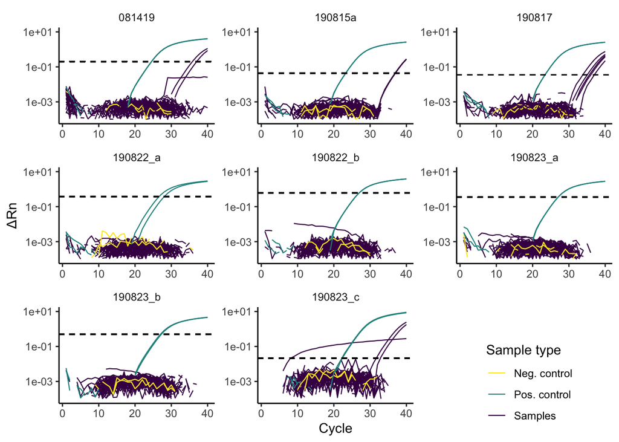

##### SI Figure 1: Response curves from qPCR analyses. Each panel represents a distinct plate run, with the date and sequence of each run identified in the panel title. Dotted lines indicate run-specific thresholds. Control positives (teal) and negatives (yellow) all performed as expected. The spurious positive result (discarded) is visible in the last plate, 190823_c.